# 3.1. Functions and Libraries

Module M-227-04: Programming for Data Analytics

Instructor: Nadežda Zeņina

## Previous lesson review

Check yourself: 2.3 Advanced Data Structures

## Today

1. **Functions**
2. **Libraries**

## Functions

If you anticipate needing to repeat the same or very similar code more than once, it may be worth writing a reusable function.

You already **use** functions: `print()`, `len()`, `input()`, `range()`. Today we learn to **write our own**.

A function works like a machine: arguments go in (11), the function applies its steps (x + 1), and a return value comes out (12)

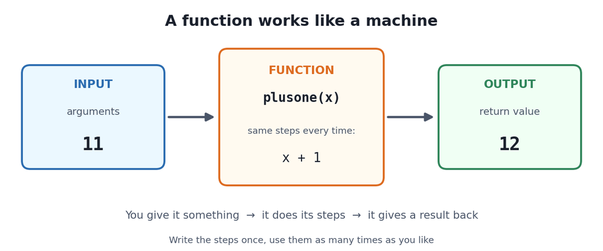

### Functions

- **parameter** - the name inside the brackets in `def` (here `x`)
- **argument** - the real value you pass when you call the function (here `11`)
- the body is **indented** (4 spaces), as in `if` and `for`
- `def` only *describes* the function. Nothing is executed until you **call** it: `plusone(11)`

```python
def plusone(x):
    "This is a short explanation on your function: this function adds 1 to the passed argument"
    print(f"Calling the 'plusone' function with argument '{x}'")
    return x+1
```

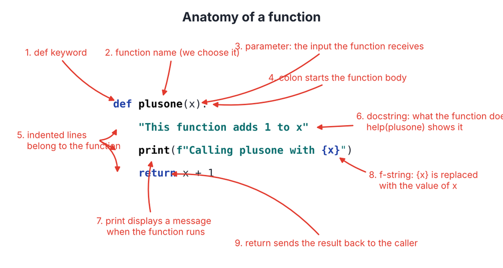

```python
print(plusone(11))
```

`help()` shows the docstring - this is how you read the documentation of any function:

```python
help(plusone)
```

### Function of two arguments

```python
def my_power(base, exponent):
    "Return the 'base' to the power of 'exponent'"
    return base**exponent
```

```python
my_power(2,3)
```

### Function arguments

- Positional vs. Keyword arguments
- Default values

Positional arguments are matched by order, keyword arguments by name, and a default value is used when an argument is not given

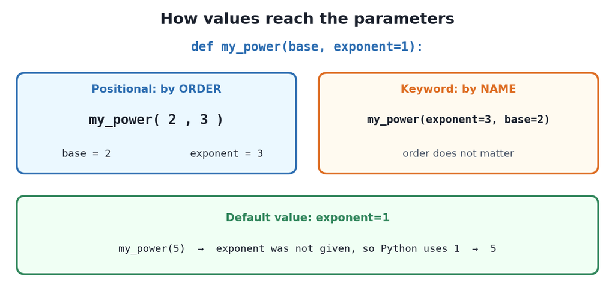

```python
def my_power(base, exponent):
    "Return the 'base' to the power of 'exponent'"
    return(base**exponent)

print(my_power(2,3))
print(my_power(3,2))
```

```python
def my_power(base, exponent=1):
    "Return the 'base' to the power of 'exponent'"
    return(base**exponent)

print(my_power(2,3))
print(my_power(3,2))
print(my_power(base=3,exponent=2))
print(my_power(exponent=2,base=3))
print(my_power(5))        # exponent is not given: the default value 1 is used
```

### Function arguments

- Multiple positional arguments

`*names` collects **any number** of values into a **tuple** (useful when you do not know in advance how many values will come).

```python
def helloAll1(*names):
    for name in names:
        print(f"Hello, {name}!")

helloAll1("John", "Jim")
```

- Multiple keyword arguments

`**namesDict` collects any number of **named** values into a **dictionary**. (useful when the number of named arguments may vary.)

```python
def helloAll2(**namesDict):
    for name in namesDict:
        print(f"Hello, {name} {namesDict[name]}!")

    #print(namesDict)

helloAll2(Mr = "John", Dr = "Jim")
```

- All types of arguments (useful when a function needs required inputs plus a flexible number of extra inputs)

The order is always: normal arguments, then `*args`, then `**kwargs`.

```python
def helloAll3(first, *names, **namesDict):
    print(f"Hello, {first}!!!!!")

    for name in names:
        print(f"Hello, {name}!")
    for name in namesDict:
        print(f"Hello, {name} {namesDict[name]}!")


helloAll3("Marta", "Jane", "Jack", Mr = "John", Dr = "Jim")
```

Let us see what exactly is collected:

```python
def show(*a, **k):
    print(type(a), a)
    print(type(k), k)

show(1, 2, 3, city="Riga", year=2026)
```

### YOUR TURN 1: writing functions

1. Write a function double(x) that returns x * 2. Call it with 5, 10, and two values of your choice.
2. Write a function subtract(a, b) with two parameters. Return the first parameter minus the second. Call it with (10, 5), (23, 6), and two more pairs of your choice.
3. Write show_languages(*languages) that prints the collected tuple. Call it with: show_languages(1, "LV", "EN")
4. Write show_record(record_id, *languages, **details) that prints: the record ID, the tuple of languages and the dictionary of details. Call it with: show_record(1, "LV", "EN", city="Riga", year=2026)
   - Expected output:
     - Record ID: 1
     - Languages: ('LV', 'EN')
     - Details: {'city': 'Riga', 'year': 2026}

### Function returns (the same calculations can return results in different forms.)

- Single value

```python
def addition(a, b):
    return a+b

#print(type(addition(2,3)))
addition(2,3)
```

- Tuple

Several values separated by commas are returned as one tuple. You can **unpack** them into separate variables.

```python
def add_multiply1(a, b):
    return a+b, a*b

#print(type(add_multiply1(2,3)))
add_multiply1(2,3)

s, p = add_multiply1(2,3)      # unpacking
print(s, p)
#print(type(s))
```

- Dictionary

A dictionary gives every returned value a meaningful name.

We access each result by its key

```python
def add_multiply2(a, b):
    return{"sum":a+b, "product":a*b}

add_multiply2(2,3)
```

### `print` is not `return`

- `print` only **shows** something on the screen
- `return` **gives the result back** to the program, so you can store it and use it later
- a function without `return` gives back `None` ("nothing")

Use print when you want to display several results in the same cell

```python
def print_double(x):
    x * 2

#print_double(4)
print(print_double(6))


def return_double(x):
    return x * 2
return_double(5)
#print(return_double(6))
```

### A function can call other functions

Big tasks are easier when split into small functions - each one does one thing.

```python
def double(x):
    return x * 2

def double_plus_one(x):
    return double(x) + 1

print(double_plus_one(4))
```

### YOUR TURN 2: function patterns

1. Write a function sum_difference(a, b) that returns the sum and the difference (a - b) as a tuple. Call it with (10, 4)
2. Write a function sum_difference_dict(a, b) that returns a dictionary with the keys "sum" and "difference". Call it with (10, 4). Store the returned dictionary in result, then print value of 'sum'

### Testing functions: Asserts

`assert condition, message` checks that the condition is `True`. If it is not, the program stops with an `AssertionError` and shows the message. This is the simplest way to **test your own function**.

```python
def plusone(x):
    return x+1
```

```python
assert plusone(1)==2, "ok"
assert add_multiply2(2,3)['product'] == 6, "ok"
```

If the function gives a wrong result, `assert` tells you immediately (this cell fails on purpose):

```python
assert plusone(2)==2, "nok"
```

## Functions are objects

Functions are the objects, so you can pass them as arguments.

A function name **without brackets** is the function itself (like any other value); with brackets `()` the function is **called**.

```python
def say_hello():
    return "Hello!"

f = say_hello          # gives the same function another name; refering function
print(f())             # the function is called
```

A function can be an argument of another function. Example: clean the list of names by applying a **list of functions** one after another:

1. `str.strip` - removes spaces around the text
2. `remove_punctuation` - removes the symbols `! # ? .`
3. `str.capitalize` - first letter big, the others small

```python
students = ('aLexey!', '    anar', '..erika', ' Jevgenijs!!! ', '##janis', 'vjaceSLAV', 'NIKITa')

import re
def remove_punctuation(value):
    return re.sub("[!#?.]", "", value)


def run_all_funcs(strings, funcs):  # applies a sequence of functions to every item and returns the results in a list
    result = []
    for value in strings:
        for func in funcs:
            value = func(value)
        result.append(value)
    return result

clean_funcs = [str.strip, remove_punctuation, str.capitalize]   # Create and choose the cleaning functions and their order

students_cleaned = run_all_funcs(students,clean_funcs)

print(students_cleaned)
```

## Namespaces

A namespace is a 'place' with a set of names and their corresponding objects. Think of two different classrooms that both have a student called Anna: when the teacher says "Anna" inside a classroom, the Anna from **this** classroom answers.

Three nested namespaces: built-in, global and local. Python looks for a name first in the local namespace, then in the global one, and last in the built-in one

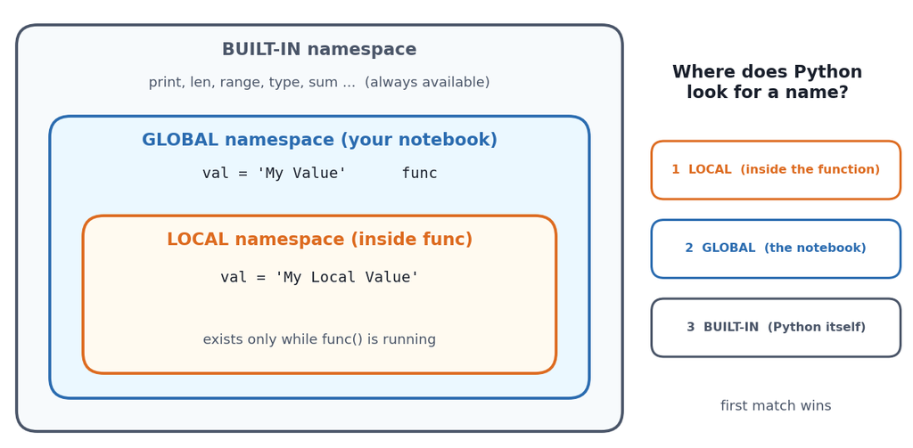

## Namespaces

- The built-in namespace contains the names of all of Python's built-in objects. These are available at all times when Python is running.
- The global namespace contains any names defined at the level of the main program. Python creates the global namespace when the main program body starts, and it remains in existence until the interpreter terminates.
- Python creates a new namespace whenever a function executes. That namespace is local to the function and remains in existence until the function terminates.

```python
val = "My Value"
def func():
    val = "My Local Value"
    print("Local value: " + val)

func()
print(val)
```

### Globals and Locals dictionaries

- globals() returns an actual reference to the dictionary that contains the global namespace
- locals() returns a dictionary that is a current copy of the local namespace, not a reference to it.

```python
val = "My Value"
def func():
    val = "My Local Value"
    local_vars = locals()
    print("Local value: " + local_vars["val"])
    global_vars = globals()
    print("Global value: " + global_vars["val"])

func()
print(val)
```

The keyword `global` lets a function change a global variable:

```python
val = "My Value"
def func():
    global val
    val = "My Local Value"

func()
print(val)
```

I recommend NOT to use *global* variables in functions while it is not absolutely necessary! Pass values as **arguments** and get the result with **return** - then the function is easy to test and to reuse.

### YOUR TURN 3: avoid global variables

Update the code so that the function receives its input as a parameter instead of using the global variable x. Call the updated function with 5 and print the returned result.

```python
x = 10

def change():
    return x * 2

print(change())
print(x)
```

## Lambda functions

Python supports *anonymous* or *lambda* functions, which are a way of writing functions consisting of a single statement, the result of which is the return value.

It's often clearer to pass a lambda function as an argument as opposed to writing a complete function declaration:

```
lambda  argument :  result
```

```python
def square(x):
    return x * x

square_lambda = lambda x: x * x      # the same function in one line
print(square(4), square_lambda(4))
```

```python
print(students_cleaned)

funcs = [lambda s: s+"! ",
        lambda s: s*3,]

run_all_funcs(students_cleaned,funcs)
```

### YOUR TURN 4: lambda functions

1. Write a function triple(x) using def that returns x * 3. Then write a lambda function named triple_lambda that performs the same calculation.

```
lambda  argument :  result
```

## Libraries

Python alone knows only the basics. **Libraries** are toolboxes written by other people - you import them and use their functions.

A library is a collection of packages, a package is a folder of modules, a module is one .py file, and a module contains functions and variables

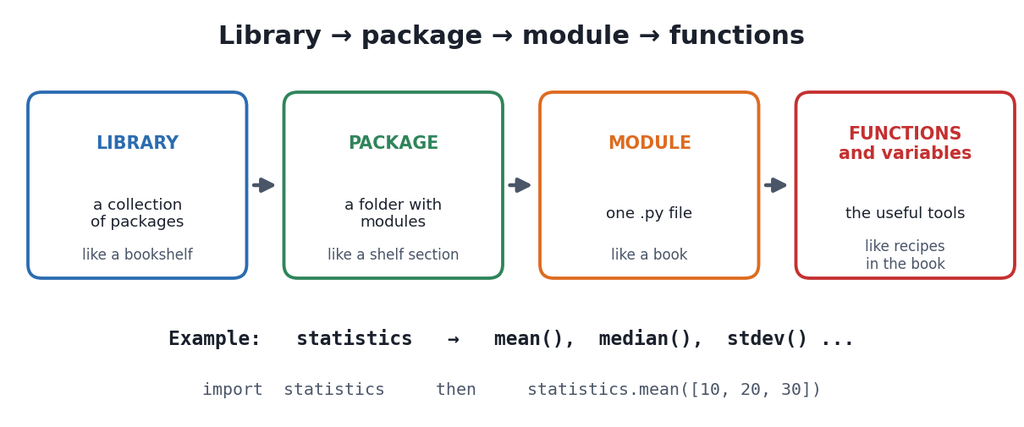

A **library** is an umbrella term referring to a reusable chunk of code. It is often assumed that while a **package** is a collection of **modules**, a **library** is a collection of **packages**.

So

- The **module** is a simple Python file that contains collections of functions and variables and with having a .py extension file.
- The **package** is a simple directory having collections of modules.
- The **library** is having a collection of packages.

## Standard libraries

- Standard (built-in) libraries are usually installed with Python
- A long list of built-in libraries https://docs.python.org/3/py-modindex.html
- Most frequently used - **math**, **random**, **statistics**, **datetime**, **json**, etc.
- Need to be imported before usage

## Importing

```python
import math
print(f"Pi is {math.pi}")
print(f"Square root of 2 is {math.sqrt(2)}")
```

- Importing all content by alias

```python
import math as my_lovely_math
print(f"Pi is {my_lovely_math.pi}")
print(f"Square root of 2 is {my_lovely_math.sqrt(2)}")
```

- Importing selected variables, functions

```python
from math import pi, sqrt
print(f"Pi is {pi}")
print(f"Square root of 2 is {sqrt(2)}")
```

- Importing all functions (not recommended) - it is hard to see where a name comes from, and names can clash with your own

```python
from math import *
print(f"Pi is {pi}")
print(f"Square root of 2 is {sqrt(2)}")
```

- Check library content: `dir()` lists all names, `help()` explains one of them

```python
import math
dir(math)
print(", ".join(dir(math)))
```

```python
help(math.sqrt)
```

## Examples

```python
import random
print(random.randint(0,100))
```

```python
import statistics
vals = [10, 30, 50, 70, 90]
print(statistics.mean(vals))
print(statistics.median(vals))
print(statistics.mode(vals))
print(statistics.stdev(vals))
```

```python
from datetime import date
print(date.today())
```

## Third-party libraries

## Installing

- **pip** installs *python* packages in *any* environment
- **conda** installs *any* package in *conda* environments

Third-party libraries (numpy, pandas, matplotlib, ...) are written by the community and are **not** included in Python - they must be installed once. In Google Colab many of them are already installed.

- **pip** from shell

pip install numpy

- **pip** from Jupyter notebook (the exclamation mark runs a shell command)

```python
!pip install numpy
```

After installation the library is imported like a standard one. By convention numpy gets the short name `np`:

```python
import numpy as np
print(np.__version__)
print(np.sqrt(16))
```

```python
%pip show numpy
```

```python
%pip list # List installed packages
```

## Your own modules

Constructing you own module is simple - just create the python script file (.py) with all your functions and use it as a built-in library.

```python
import mylib

mylib.myprint("Nadezda")
```

### Module: search paths

Python looks for modules in these folders (the first one is the current folder - that is why `mylib.py` must be next to the notebook):

```python
import sys
sys.path
```

### Module: content

```python
print(dir(mylib))
```

```python
with open('mylib.py') as f:
    print("Content of the mylib library")
    print("---> start of content")
    print(f.read())
    print("<--- end of content")
```

### if __name__ == "__main__":

This statement allows distinguishing two cases:

- running the script as a separate programme (**True** in this case)
- loading the script as a library (**False** in this case)

Use it for code that must run only when you start the file directly (for example tests or a demo).

If a file is run as a program, **name** is "**main**" and the block runs; if it is imported as a library, **name** is the module name and the block is skipped

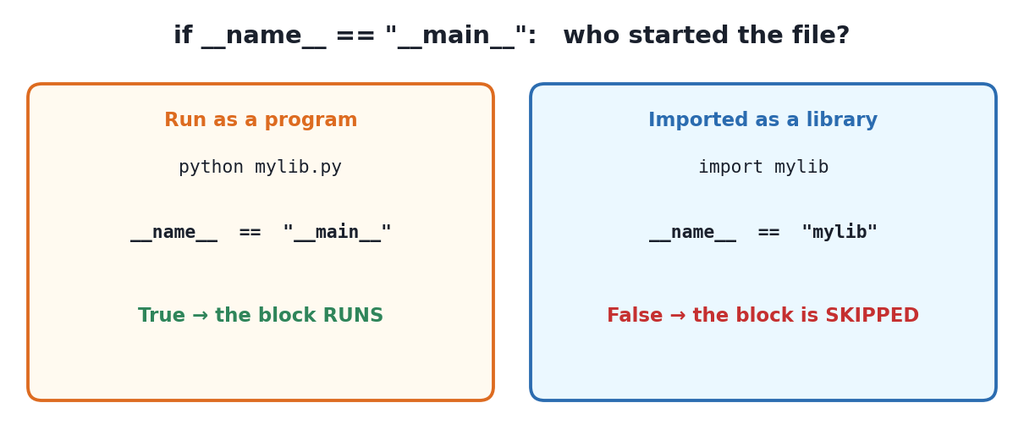

**Run as a program** (the block runs):

```python
!python mylib.py
```

**Import as a library** (nothing is printed - the block is skipped). Python remembers an already imported module, so we reload it after the change:

```python
import importlib
import mylib
importlib.reload(mylib)
print("name inside the notebook:", __name__)
print("name of the module     :", mylib.__name__)
```

## Summary

- **def** creates a function; **return** gives the result back (without return you get `None`)
- arguments: positional, keyword, default values, `*args`, `**kwargs`; a function can return one value, a tuple or a dictionary
- `assert` tests a function; functions are objects; local names hide global names; **lambda** is a one-line function
- **import** gives access to libraries: standard (`math`, `random`, `statistics`), third-party (`pip install`) and your own modules (`.py` file)